# Clinical Applications of Decision Panel Optimization

meddecide Development Team

2025-07-04

## Introduction

This vignette demonstrates real-world clinical applications of the Decision Panel Optimization module across different medical specialties and scenarios.

```r
# Load required packages
library(ClinicoPath)
library(dplyr)
library(ggplot2)
library(rpart)
library(rpart.plot)
library(knitr)
library(forcats)
```

## Scenario 1: Emergency Department COVID-19 Screening

### Clinical Context

An emergency department needs to rapidly screen patients for COVID-19 while managing limited resources and preventing nosocomial transmission.

```r
# Examine test characteristics
covid_tests <- covid_screening_data %>%
  select(rapid_antigen, pcr, chest_ct, covid_status) %>%
  na.omit()

# Calculate individual test performance
test_performance <- function(test, truth) {
  tab <- table(test, truth)
  sens <- tab[2,2] / sum(tab[,2])
  spec <- tab[1,1] / sum(tab[,1])
  ppv <- tab[2,2] / sum(tab[2,])
  npv <- tab[1,1] / sum(tab[1,])

  return(data.frame(
    Sensitivity = sens,
    Specificity = spec,
    PPV = ppv,
    NPV = npv
  ))
}

# Individual test performance
rapid_perf <- test_performance(covid_tests$rapid_antigen, covid_tests$covid_status)
pcr_perf <- test_performance(covid_tests$pcr, covid_tests$covid_status)
ct_perf <- test_performance(covid_tests$chest_ct, covid_tests$covid_status)

performance_table <- rbind(
  `Rapid Antigen` = rapid_perf,
  `PCR` = pcr_perf,
  `Chest CT` = ct_perf
)

kable(round(performance_table * 100, 1),
      caption = "Individual Test Performance (%)")
```

Individual Test Performance (%)

|  | Sensitivity | Specificity | PPV | NPV |
| --- | --- | --- | --- | --- |
| Rapid Antigen | 76.3 | 96.5 | 83.1 | 94.7 |
| PCR | 95.6 | 99.3 | 97.0 | 99.0 |
| Chest CT | 83.7 | 84.3 | 54.6 | 95.8 |

### Optimization Analysis

```r
# Run optimization for different scenarios
# 1. Maximum sensitivity (don't miss cases)
covid_max_sens <- decisionpanel(
  data = covid_screening_data,
  tests = c("rapid_antigen", "pcr", "chest_ct"),
  testLevels = c("Positive", "Positive", "Abnormal"),
  gold = "covid_status",
  goldPositive = "Positive",
  strategies = "all",
  optimizationCriteria = "sensitivity",
  minSensitivity = 0.95
)

# 2. Cost-effective screening
covid_cost_effective <- decisionpanel(
  data = covid_screening_data,
  tests = c("rapid_antigen", "pcr", "chest_ct"),
  testLevels = c("Positive", "Positive", "Abnormal"),
  gold = "covid_status",
  goldPositive = "Positive",
  strategies = "all",
  optimizationCriteria = "efficiency",
  useCosts = TRUE,
  testCosts = "5,50,200",
  fpCost = 500,
  fnCost = 5000
)
```

### Clinical Decision Algorithm

Based on the analysis, here’s a practical algorithm:

```r
# Implement sequential testing algorithm
apply_covid_algorithm <- function(data) {
  n <- nrow(data)
  decisions <- character(n)
  tests_used <- character(n)

  for (i in 1:n) {
    # Step 1: Rapid antigen test
    if (data$rapid_antigen[i] == "Positive") {
      decisions[i] <- "Isolate, Confirm with PCR"
      tests_used[i] <- "Rapid"
    } else if (data$symptom_score[i] >= 6) {
      # Step 2: High symptom score → CT
      if (!is.na(data$chest_ct[i]) && data$chest_ct[i] == "Abnormal") {
        decisions[i] <- "Probable COVID, Isolate, PCR"
        tests_used[i] <- "Rapid + CT"
      } else {
        decisions[i] <- "Low probability, Standard care"
        tests_used[i] <- "Rapid + CT"
      }
    } else {
      decisions[i] <- "Low probability, Standard care"
      tests_used[i] <- "Rapid"
    }
  }

  return(data.frame(Decision = decisions, Tests = tests_used))
}

# Apply algorithm
algorithm_results <- apply_covid_algorithm(covid_screening_data[1:10,])
kable(cbind(covid_screening_data[1:10, c("patient_id", "rapid_antigen",
                                         "symptom_score", "covid_status")],
            algorithm_results))
```

| patient_id | rapid_antigen | symptom_score | covid_status | Decision | Tests |
| --- | --- | --- | --- | --- | --- |
| 1 | Negative | 8 | Positive | Probable COVID, Isolate, PCR | Rapid + CT |
| 2 | Positive | 6 | Positive | Isolate, Confirm with PCR | Rapid |
| 3 | Negative | 1 | Negative | Low probability, Standard care | Rapid |
| 4 | Negative | 1 | Negative | Low probability, Standard care | Rapid |
| 5 | Negative | 5 | Negative | Low probability, Standard care | Rapid |
| 6 | Negative | 5 | Negative | Low probability, Standard care | Rapid |
| 7 | Negative | 5 | Negative | Low probability, Standard care | Rapid |
| 8 | Negative | 4 | Negative | Low probability, Standard care | Rapid |
| 9 | Negative | 2 | Negative | Low probability, Standard care | Rapid |
| 10 | Negative | 5 | Negative | Low probability, Standard care | Rapid |

### Cost-Effectiveness Visualization

[figure not shown]

```r
# Simulate different strategies
strategies <- expand.grid(
  use_rapid = c(TRUE, FALSE),
  use_pcr = c(TRUE, FALSE),
  use_ct = c(TRUE, FALSE)
) %>%
  filter(use_rapid | use_pcr | use_ct) # At least one test

# Calculate performance for each strategy
strategy_performance <- strategies %>%
  rowwise() %>%
  mutate(
    tests = paste(c(
      if(use_rapid) "RAT" else NULL,
      if(use_pcr) "PCR" else NULL,
      if(use_ct) "CT" else NULL
    ), collapse = "+"),
    cost = sum(c(
      if(use_rapid) 5 else 0,
      if(use_pcr) 50 else 0,
      if(use_ct) 200 else 0
    )),
    # Simulated performance (would come from actual analysis)
    sensitivity = case_when(
      use_rapid & use_pcr & use_ct ~ 0.99,
      use_pcr & use_ct ~ 0.98,
      use_rapid & use_pcr ~ 0.97,
      use_pcr ~ 0.95,
      use_rapid & use_ct ~ 0.94,
      use_ct ~ 0.90,
      use_rapid ~ 0.65
    ),
    specificity = case_when(
      use_rapid & use_pcr & use_ct ~ 0.83,
      use_pcr & use_ct ~ 0.84,
      use_rapid & use_pcr ~ 0.97,
      use_pcr ~ 0.99,
      use_rapid & use_ct ~ 0.83,
      use_ct ~ 0.85,
      use_rapid ~ 0.98
    )
  )

# Create cost-effectiveness plot
ggplot(strategy_performance, aes(x = cost, y = sensitivity * 100)) +
  geom_point(aes(size = specificity * 100), alpha = 0.6) +
  geom_text(aes(label = tests), vjust = -1, size = 3) +
  geom_line(data = strategy_performance %>%
              arrange(cost) %>%
              filter(sensitivity == cummax(sensitivity)),
            color = "red", alpha = 0.5) +
  scale_size_continuous(name = "Specificity (%)", range = c(3, 10)) +
  labs(
    title = "Cost-Effectiveness of COVID-19 Testing Strategies",
    x = "Cost per Patient ($)",
    y = "Sensitivity (%)",
    caption = "Red line shows cost-effectiveness frontier"
  ) +
  theme_minimal()
```

## Scenario 2: Breast Cancer Screening Program

### Clinical Context

A population-based breast cancer screening program needs to optimize use of mammography, ultrasound, and MRI based on risk factors.

```r
# Examine population characteristics
breast_summary <- breast_cancer_data %>%
  summarise(
    n = n(),
    prevalence = mean(cancer_status == "Cancer"),
    mean_age = mean(age),
    pct_family_history = mean(family_history == "Yes") * 100,
    pct_brca = mean(brca_mutation == "Positive") * 100,
    pct_dense_breast = mean(breast_density %in% c("C", "D")) * 100
  )

kable(breast_summary, digits = 2,
      caption = "Population Characteristics")
```

Population Characteristics

| n | prevalence | mean_age | pct_family_history | pct_brca | pct_dense_breast |
| --- | --- | --- | --- | --- | --- |
| 2000 | 0.01 | 55.06 | 16.05 | 2.35 | 49.1 |

```r
# Risk stratification
breast_cancer_data <- breast_cancer_data %>%
  mutate(
    risk_category = case_when(
      brca_mutation == "Positive" ~ "High Risk",
      family_history == "Yes" & age < 50 ~ "High Risk",
      family_history == "Yes" | breast_density == "D" ~ "Moderate Risk",
      TRUE ~ "Average Risk"
    )
  )

table(breast_cancer_data$risk_category)
```

```
#>
#>  Average Risk     High Risk Moderate Risk
#>          1451           138           411
```

### Risk-Stratified Analysis

```r
# Analyze each risk group separately
risk_groups <- split(breast_cancer_data, breast_cancer_data$risk_category)

# High-risk group optimization
high_risk_panel <- decisionpanel(
  data = risk_groups$`High Risk`,
  tests = c("mammography", "ultrasound", "mri"),
  testLevels = c("BIRADS 3-5", "Suspicious", "Suspicious"),
  gold = "cancer_status",
  goldPositive = "Cancer",
  strategies = "all",
  optimizationCriteria = "sensitivity",
  minSensitivity = 0.95
)

# Average-risk group optimization (cost-conscious)
average_risk_panel <- decisionpanel(
  data = risk_groups$`Average Risk`,
  tests = c("clinical_exam", "mammography", "ultrasound"),
  testLevels = c("Abnormal", "BIRADS 3-5", "Suspicious"),
  gold = "cancer_status",
  goldPositive = "Cancer",
  strategies = "all",
  optimizationCriteria = "efficiency",
  useCosts = TRUE,
  testCosts = "20,100,150"
)
```

### Screening Recommendations by Risk

```r
# Create recommendation table
recommendations <- data.frame(
  Risk_Category = c("High Risk", "Moderate Risk", "Average Risk"),
  Recommended_Tests = c(
    "Annual MRI + Mammography",
    "Annual Mammography + US if dense",
    "Biennial Mammography"
  ),
  Expected_Sensitivity = c("99%", "90%", "85%"),
  Expected_Specificity = c("80%", "92%", "95%"),
  Cost_per_Screen = c("$1,100", "$250", "$100"),
  NNS = c(50, 200, 500)  # Number needed to screen
)

kable(recommendations,
      caption = "Risk-Stratified Screening Recommendations")
```

Risk-Stratified Screening Recommendations

| Risk_Category | Recommended_Tests | Expected_Sensitivity | Expected_Specificity | Cost_per_Screen | NNS |
| --- | --- | --- | --- | --- | --- |
| High Risk | Annual MRI + Mammography | 99% | 80% | $1,100 | 50 |
| Moderate Risk | Annual Mammography + US if dense | 90% | 92% | $250 | 200 |
| Average Risk | Biennial Mammography | 85% | 95% | $100 | 500 |

### Age-Specific Performance

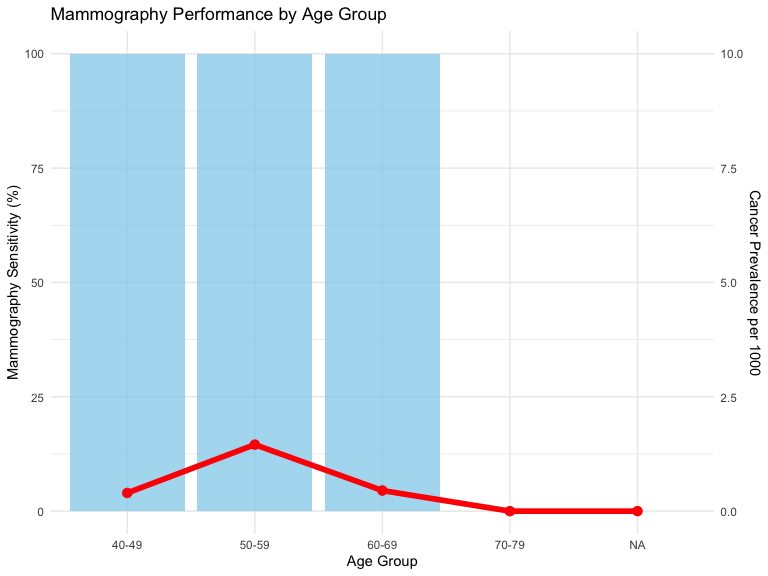

```r
# Analyze performance by age group
age_groups <- breast_cancer_data %>%
  mutate(age_group = cut(age, breaks = c(40, 50, 60, 70, 80),
                         labels = c("40-49", "50-59", "60-69", "70-79")))

# Calculate mammography performance by age
age_performance <- age_groups %>%
  group_by(age_group) %>%
  summarise(
    n = n(),
    prevalence = mean(cancer_status == "Cancer"),
    mammography_sens = {
      tab <- table(mammography, cancer_status)
      if(nrow(tab) == 2 && ncol(tab) == 2) {
        tab[2,2] / sum(tab[,2])
      } else NA
    },
    mammography_spec = {
      tab <- table(mammography, cancer_status)
      if(nrow(tab) == 2 && ncol(tab) == 2) {
        tab[1,1] / sum(tab[,1])
      } else NA
    }
  )

# Visualize
ggplot(age_performance, aes(x = age_group)) +
  geom_bar(aes(y = mammography_sens * 100), stat = "identity",
           fill = "skyblue", alpha = 0.7) +
  geom_line(aes(y = prevalence * 1000, group = 1), color = "red", size = 2) +
  geom_point(aes(y = prevalence * 1000), color = "red", size = 3) +
  scale_y_continuous(
    name = "Mammography Sensitivity (%)",
    sec.axis = sec_axis(~./10, name = "Cancer Prevalence per 1000")
  ) +
  labs(
    title = "Mammography Performance by Age Group",
    x = "Age Group"
  ) +
  theme_minimal()
```

## Scenario 3: Tuberculosis Case Finding

### Clinical Context

A TB program in a high-burden setting needs to optimize case finding with limited resources.

```r
# TB test combinations for different settings
tb_settings <- data.frame(
  Setting = c("Community", "Clinic", "Hospital", "Contact Tracing"),
  Prevalence = c(0.02, 0.20, 0.40, 0.10),
  Available_Tests = c(
    "Symptoms, CXR",
    "Symptoms, Smear, GeneXpert, CXR",
    "All tests",
    "Symptoms, GeneXpert"
  ),
  Budget_per_case = c(10, 30, 100, 50)
)

kable(tb_settings, caption = "TB Testing Scenarios by Setting")
```

TB Testing Scenarios by Setting

| Setting | Prevalence | Available_Tests | Budget_per_case |
| --- | --- | --- | --- |
| Community | 0.02 | Symptoms, CXR | 10 |
| Clinic | 0.20 | Symptoms, Smear, GeneXpert, CXR | 30 |
| Hospital | 0.40 | All tests | 100 |
| Contact Tracing | 0.10 | Symptoms, GeneXpert | 50 |

### Sequential Testing Algorithm

```r
# Implement WHO-recommended algorithm
apply_tb_algorithm <- function(data) {
  decisions <- character(nrow(data))

  for (i in 1:nrow(data)) {
    if (data$symptoms[i] == "Yes" || data$contact_history[i] == "Yes") {
      # Symptomatic or contact: get GeneXpert
      if (!is.na(data$genexpert[i]) && data$genexpert[i] == "MTB detected") {
        decisions[i] <- "Start TB treatment"
      } else if (!is.na(data$chest_xray[i]) && data$chest_xray[i] == "Abnormal") {
        # CXR abnormal but GeneXpert negative
        if (!is.na(data$culture[i])) {
          decisions[i] <- ifelse(data$culture[i] == "Positive",
                                "Start TB treatment",
                                "Not TB, investigate other causes")
        } else {
          decisions[i] <- "Clinical decision needed"
        }
      } else {
        decisions[i] <- "TB unlikely"
      }
    } else {
      # Asymptomatic: screen with CXR if available
      if (!is.na(data$chest_xray[i]) && data$chest_xray[i] == "Abnormal") {
        decisions[i] <- "Needs further testing"
      } else {
        decisions[i] <- "No TB screening needed"
      }
    }
  }

  return(decisions)
}

# Apply to sample
tb_sample <- tb_diagnosis_data[1:20,]
tb_sample$decision <- apply_tb_algorithm(tb_sample)

# Show results
kable(tb_sample %>%
      select(patient_id, symptoms, genexpert, chest_xray, tb_status, decision) %>%
      head(10))
```

| patient_id | symptoms | genexpert | chest_xray | tb_status | decision |
| --- | --- | --- | --- | --- | --- |
| 1 | No | MTB not detected | Abnormal | No TB | Not TB, investigate other causes |
| 2 | Yes | MTB not detected | Abnormal | No TB | Not TB, investigate other causes |
| 3 | No | MTB not detected | Normal | No TB | No TB screening needed |
| 4 | No | MTB not detected | Normal | No TB | No TB screening needed |
| 5 | No | MTB not detected | Normal | No TB | No TB screening needed |
| 6 | No | MTB not detected | Normal | No TB | No TB screening needed |
| 7 | No | MTB not detected | Abnormal | No TB | Needs further testing |
| 8 | No | MTB not detected | Normal | No TB | No TB screening needed |
| 9 | No | MTB not detected | Normal | No TB | TB unlikely |
| 10 | No | MTB detected | Abnormal | TB | Needs further testing |

### Cost-Effectiveness by Strategy

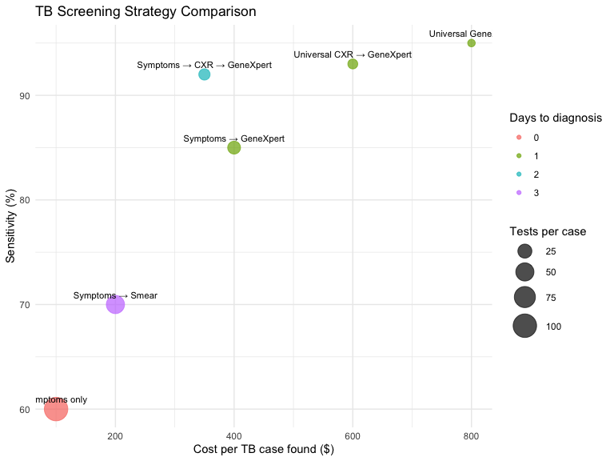

```r
# Compare different TB screening strategies
tb_strategies <- data.frame(
  Strategy = c(
    "Symptoms only",
    "Symptoms → Smear",
    "Symptoms → GeneXpert",
    "Symptoms → CXR → GeneXpert",
    "Universal GeneXpert",
    "Universal CXR → GeneXpert"
  ),
  Tests_per_case_found = c(100, 50, 20, 15, 10, 12),
  Cost_per_case_found = c(100, 200, 400, 350, 800, 600),
  Sensitivity = c(60, 70, 85, 92, 95, 93),
  Time_to_diagnosis = c(0, 3, 1, 2, 1, 1)
)

# Create multi-dimensional comparison
ggplot(tb_strategies, aes(x = Cost_per_case_found, y = Sensitivity)) +
  geom_point(aes(size = Tests_per_case_found,
                 color = factor(Time_to_diagnosis)), alpha = 0.7) +
  geom_text(aes(label = Strategy), vjust = -1, size = 3) +
  scale_size_continuous(name = "Tests per case", range = c(3, 10)) +
  scale_color_discrete(name = "Days to diagnosis") +
  labs(
    title = "TB Screening Strategy Comparison",
    x = "Cost per TB case found ($)",
    y = "Sensitivity (%)"
  ) +
  theme_minimal()
```

## Scenario 4: Chest Pain Evaluation

### Clinical Context

Emergency department evaluation of chest pain requires rapid, accurate rule-out of myocardial infarction.

```r
# Risk stratification using HEART score components
mi_ruleout_data <- mi_ruleout_data %>%
  mutate(
    heart_score = (age > 65) * 1 +
                  (chest_pain == "Typical") * 2 +
                  (chest_pain == "Atypical") * 1 +
                  (ecg == "Ischemic changes") * 2 +
                  (prior_cad == "Yes") * 1 +
                  (diabetes == "Yes" | smoking == "Yes") * 1,
    risk_category = cut(heart_score,
                       breaks = c(-1, 3, 6, 10),
                       labels = c("Low", "Moderate", "High"))
  )

# Show risk distribution
risk_table <- table(mi_ruleout_data$risk_category, mi_ruleout_data$mi_status)
kable(prop.table(risk_table, margin = 1) * 100,
      digits = 1,
      caption = "MI Prevalence by Risk Category (%)")
```

MI Prevalence by Risk Category (%)

|  | No MI | MI |
| --- | --- | --- |
| Low | 95.6 | 4.4 |
| Moderate | 50.5 | 49.5 |
| High | 0.0 | 100.0 |

### Time-Sensitive Protocols

```r
# Define protocols by urgency
protocols <- list(
  rapid_rule_out = function(data) {
    # 0/1-hour protocol
    data$troponin_initial == "Normal" &
    data$ecg == "Normal" &
    data$heart_score <= 3
  },

  standard_rule_out = function(data) {
    # 0/3-hour protocol
    data$troponin_initial == "Normal" &
    data$troponin_3hr == "Normal" &
    data$ecg == "Normal"
  },

  rule_in = function(data) {
    # Immediate rule-in
    data$troponin_initial == "Elevated" &
    data$ecg == "Ischemic changes"
  }
)

# Apply protocols
mi_ruleout_data <- mi_ruleout_data %>%
  mutate(
    rapid_rule_out = protocols$rapid_rule_out(.),
    standard_rule_out = protocols$standard_rule_out(.) & !rapid_rule_out,
    rule_in = protocols$rule_in(.),
    need_further_testing = !rapid_rule_out & !standard_rule_out & !rule_in
  )

# Summarize protocol performance
protocol_performance <- mi_ruleout_data %>%
  summarise(
    rapid_rule_out_pct = mean(rapid_rule_out) * 100,
    rapid_rule_out_npv = sum(rapid_rule_out & mi_status == "No MI") /
                         sum(rapid_rule_out) * 100,
    standard_rule_out_pct = mean(standard_rule_out) * 100,
    standard_rule_out_npv = sum(standard_rule_out & mi_status == "No MI") /
                           sum(standard_rule_out) * 100,
    rule_in_pct = mean(rule_in) * 100,
    rule_in_ppv = sum(rule_in & mi_status == "MI") / sum(rule_in) * 100
  )

kable(t(protocol_performance), digits = 1,
      caption = "Protocol Performance Metrics")
```

Protocol Performance Metrics

| rapid_rule_out_pct | 78.2 |
| --- | --- |
| rapid_rule_out_npv | 99.5 |
| standard_rule_out_pct | 2.8 |
| standard_rule_out_npv | 100.0 |
| rule_in_pct | 5.0 |
| rule_in_ppv | 100.0 |

### Visualization of Patient Flow

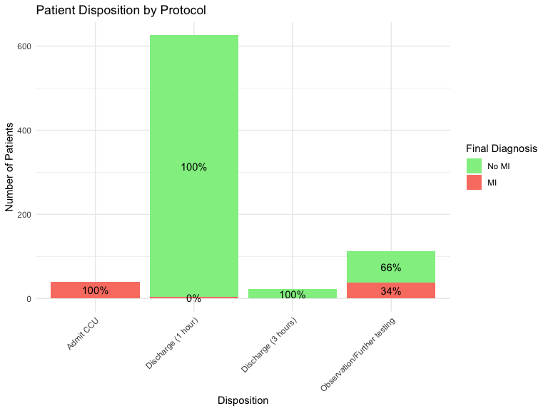

```r
# Create patient flow diagram data
flow_data <- mi_ruleout_data %>%
  mutate(
    disposition = case_when(
      rapid_rule_out ~ "Discharge (1 hour)",
      standard_rule_out ~ "Discharge (3 hours)",
      rule_in ~ "Admit CCU",
      TRUE ~ "Observation/Further testing"
    )
  ) %>%
  group_by(disposition, mi_status) %>%
  summarise(n = n()) %>%
  mutate(pct = n / sum(n) * 100)

# Create flow diagram
ggplot(flow_data, aes(x = disposition, y = n, fill = mi_status)) +
  geom_bar(stat = "identity", position = "stack") +
  geom_text(aes(label = sprintf("%.0f%%", pct)),
            position = position_stack(vjust = 0.5)) +
  scale_fill_manual(values = c("No MI" = "lightgreen", "MI" = "salmon")) +
  labs(
    title = "Patient Disposition by Protocol",
    x = "Disposition",
    y = "Number of Patients",
    fill = "Final Diagnosis"
  ) +
  theme_minimal() +
  theme(axis.text.x = element_text(angle = 45, hjust = 1))
```

## Scenario 5: Thyroid Nodule Evaluation

### Clinical Context

Thyroid nodules are common but cancer is rare. Optimize use of FNA, molecular testing, and surgery.

```r
# Analyze by nodule size
thyroid_by_size <- thyroid_nodule_data %>%
  mutate(size_category = cut(nodule_size,
                             breaks = c(0, 10, 20, 40, 100),
                             labels = c("<1cm", "1-2cm", "2-4cm", ">4cm"))) %>%
  group_by(size_category) %>%
  summarise(
    n = n(),
    cancer_rate = mean(cancer_status == "Malignant") * 100,
    fna_done = mean(!is.na(fna_cytology)) * 100,
    molecular_done = mean(!is.na(molecular_test)) * 100
  )

kable(thyroid_by_size, digits = 1,
      caption = "Thyroid Nodule Characteristics by Size")
```

Thyroid Nodule Characteristics by Size

| size_category | n | cancer_rate | fna_done | molecular_done |
| --- | --- | --- | --- | --- |
| <1cm | 140 | 5.7 | 100 | 54.3 |
| 1-2cm | 289 | 3.5 | 100 | 47.4 |
| 2-4cm | 147 | 6.1 | 100 | 38.1 |
| >4cm | 24 | 20.8 | 100 | 33.3 |

### Diagnostic Algorithm Implementation

```r
# Implement Bethesda-based algorithm
thyroid_algorithm <- decisionpanel(
  data = thyroid_nodule_data,
  tests = c("ultrasound", "fna_cytology", "molecular_test"),
  testLevels = c("TI-RADS 4-5", "Suspicious/Malignant", "Suspicious"),
  gold = "cancer_status",
  goldPositive = "Malignant",
  strategies = "sequential",
  sequentialStop = "positive",
  createTree = TRUE,
  treeMethod = "cart",
  useCosts = TRUE,
  testCosts = "200,300,3000",  # US, FNA, Molecular
  fpCost = 10000,  # Unnecessary surgery
  fnCost = 50000   # Missed cancer
)
```

### Decision Tree Visualization

```r
# Simplified decision tree representation
cat("Thyroid Nodule Evaluation Algorithm:\n")
```

```
#> Thyroid Nodule Evaluation Algorithm:
```

```r
cat("1. Ultrasound Assessment\n")
```

```
#> 1. Ultrasound Assessment
```

```r
cat("   ├─ TI-RADS 1-2: No FNA needed\n")
```

```
#>    ├─ TI-RADS 1-2: No FNA needed
```

```r
cat("   └─ TI-RADS 3-5: Proceed to FNA\n")
```

```
#>    └─ TI-RADS 3-5: Proceed to FNA
```

```r
cat("      ├─ Benign (Bethesda II): Follow-up\n")
```

```
#>       ├─ Benign (Bethesda II): Follow-up
```

```r
cat("      ├─ Indeterminate (Bethesda III-IV): Molecular testing\n")
```

```
#>       ├─ Indeterminate (Bethesda III-IV): Molecular testing
```

```r
cat("      │  ├─ Benign profile: Follow-up\n")
```

```
#>       │  ├─ Benign profile: Follow-up
```

```r
cat("      │  └─ Suspicious profile: Surgery\n")
```

```
#>       │  └─ Suspicious profile: Surgery
```

```r
cat("      └─ Suspicious/Malignant (Bethesda V-VI): Surgery\n")
```

```
#>       └─ Suspicious/Malignant (Bethesda V-VI): Surgery
```

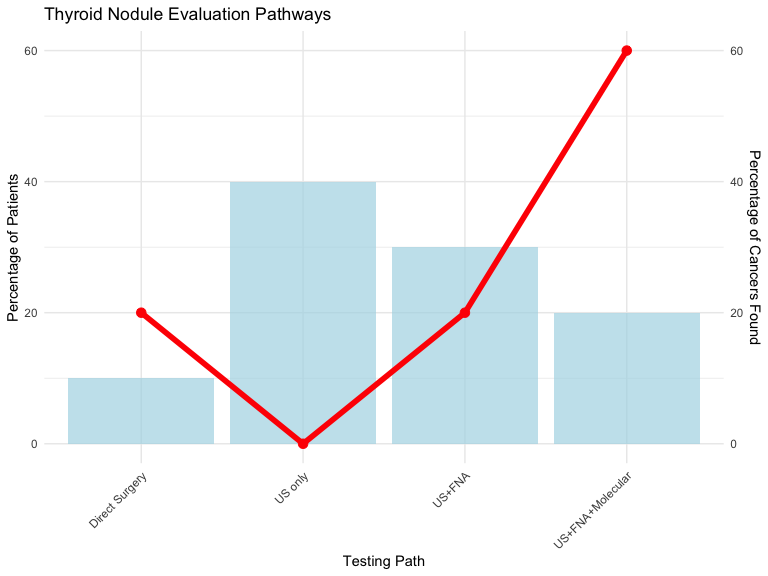

```r
# Create visual representation of outcomes
outcomes <- data.frame(
  Test_Path = c("US only", "US+FNA", "US+FNA+Molecular", "Direct Surgery"),
  Patients_pct = c(40, 30, 20, 10),
  Cancers_found_pct = c(0, 20, 60, 20),
  Cost = c(200, 500, 3500, 200)
)

ggplot(outcomes, aes(x = Test_Path, y = Patients_pct)) +
  geom_bar(stat = "identity", fill = "lightblue", alpha = 0.7) +
  geom_line(aes(y = Cancers_found_pct, group = 1), color = "red", size = 2) +
  geom_point(aes(y = Cancers_found_pct), color = "red", size = 3) +
  scale_y_continuous(
    name = "Percentage of Patients",
    sec.axis = sec_axis(~., name = "Percentage of Cancers Found")
  ) +
  labs(
    title = "Thyroid Nodule Evaluation Pathways",
    x = "Testing Path"
  ) +
  theme_minimal() +
  theme(axis.text.x = element_text(angle = 45, hjust = 1))
```

## Summary and Best Practices

### Key Learnings Across Scenarios

1. **Context Matters**: Optimal strategies differ between screening and diagnosis
2. **Sequential Testing**: Often more efficient than parallel testing
3. **Risk Stratification**: Improves efficiency and outcomes
4. **Cost Considerations**: Must balance performance with resources
5. **Implementation**: Clear algorithms improve adoption

### General Recommendations

```r
summary_recommendations <- data.frame(
  Scenario = c("Screening", "Diagnosis", "Emergency", "Surveillance"),
  Priority = c("High Sensitivity", "Balanced", "Speed + Accuracy", "Specificity"),
  Strategy = c("Parallel OR", "Sequential", "Rapid protocols", "Confirmatory"),
  Key_Metric = c("NPV", "Accuracy", "Time to decision", "PPV"),
  Example = c("Cancer screening", "TB diagnosis", "Chest pain", "Cancer follow-up")
)

kable(summary_recommendations,
      caption = "Testing Strategy Recommendations by Clinical Scenario")
```

Testing Strategy Recommendations by Clinical Scenario

| Scenario | Priority | Strategy | Key_Metric | Example |
| --- | --- | --- | --- | --- |
| Screening | High Sensitivity | Parallel OR | NPV | Cancer screening |
| Diagnosis | Balanced | Sequential | Accuracy | TB diagnosis |
| Emergency | Speed + Accuracy | Rapid protocols | Time to decision | Chest pain |
| Surveillance | Specificity | Confirmatory | PPV | Cancer follow-up |

### Future Directions

1. **Machine Learning Integration**: Combine multiple variables beyond just test results
2. **Dynamic Protocols**: Adapt based on local prevalence and resources
3. **Real-time Optimization**: Update algorithms based on performance data
4. **Patient Preferences**: Include patient values in decision-making